# Law Firm Absenteeism - Multiple Linear Regression

Faith Kabanda

## Project Summary

A Director at a hypothetical small Zimbabwean law firm is concerned about employee absenteeism among staff. She believes that organisation commitment is probably the most significant contributing factor. She selected a random sample of 31 employee files and noted their level of absenteeism (in days p.a.). She sent a confidential questionnaire to each of the selected employees from which an organisation commitment index was derived. The Director is interested in the possible effect that other factors such as job tenure (time in months at the organisation), and grade (1 = clerk, 2 = consultant, 3 = lawyer) have on the level of employee absenteeism. Multiple linear regression of the data with commitment, job tenure and grade as independent variables is used to help the Director understand factors, if any, that are contributing to employees’ absenteeism. NB: For the variable grade, two dummy variables were used.

### Import Dataset Using Readxl

```r
library(readxl)
law_firm_data <- read_excel("C:/Users/Faith Kabanda/OneDrive/Documents/Data Analysis Portfolio By Faith Kabanda/Data-Analyst-Portfolio-By-Faith-Kabanda/Project 4 - Multiple Regression Analysis in R/Law Firm Absenteeism Data - Multiple Linear Regression.xlsx",
    sheet = "Data")
head(law_firm_data) #to get the first few rows of the data
```

```
## # A tibble: 6 × 7
##   Absence Commitment Tenure `Employee Grade` Clerk Consultant Lawyer
##     <dbl>      <dbl>  <dbl>            <dbl> <dbl>      <dbl>  <dbl>
## 1      23         49    143                2     0          1      0
## 2      26         40    125                2     0          1      0
## 3      18         69     95                2     0          1      0
## 4      12         72     84                1     1          0      0
## 5      30         26    164                3     0          0      1
## 6       9         78     67                1     1          0      0
```

```r
#Create a table

library(kableExtra)
library(knitr)
library(dplyr)
library(reshape2)
law_firm_data %>% head() %>% kable() %>% column_spec(1:6,border_left = T, border_right = T) %>% kable_styling("striped")
```

| Absence | Commitment | Tenure | Employee Grade | Clerk | Consultant | Lawyer |
| --- | --- | --- | --- | --- | --- | --- |
| 23 | 49 | 143 | 2 | 0 | 1 | 0 |
| 26 | 40 | 125 | 2 | 0 | 1 | 0 |
| 18 | 69 | 95 | 2 | 0 | 1 | 0 |
| 12 | 72 | 84 | 1 | 1 | 0 | 0 |
| 30 | 26 | 164 | 3 | 0 | 0 | 1 |
| 9 | 78 | 67 | 1 | 1 | 0 | 0 |

```r
#This code gives 6 columns in total and kable_styling gives proportional rows and columns giving rise equally size cells/small boxes. Lastly, removing  %>% head() will give the full tabl
# Generate table [from kable() function] in MS Word: Highlight raw data > insert > insert table > convert text to table > select  the right # of columns > enter.
```

### Understanding The Data Using Summary Statistics

```r
summary(law_firm_data$Absence)
```

```
##    Min. 1st Qu.  Median    Mean 3rd Qu.    Max.
##    5.00   13.50   20.00   19.65   25.50   36.00
```

```r
summary(law_firm_data$Commitment)
```

```
##    Min. 1st Qu.  Median    Mean 3rd Qu.    Max.
##   19.00   40.00   49.00   51.74   65.00   82.00
```

```r
summary(law_firm_data$Tenure)
```

```
##    Min. 1st Qu.  Median    Mean 3rd Qu.    Max.
##    24.0    65.5   120.0   107.6   144.5   189.0
```

### Understanding The Relationship Between Absence And Commitment

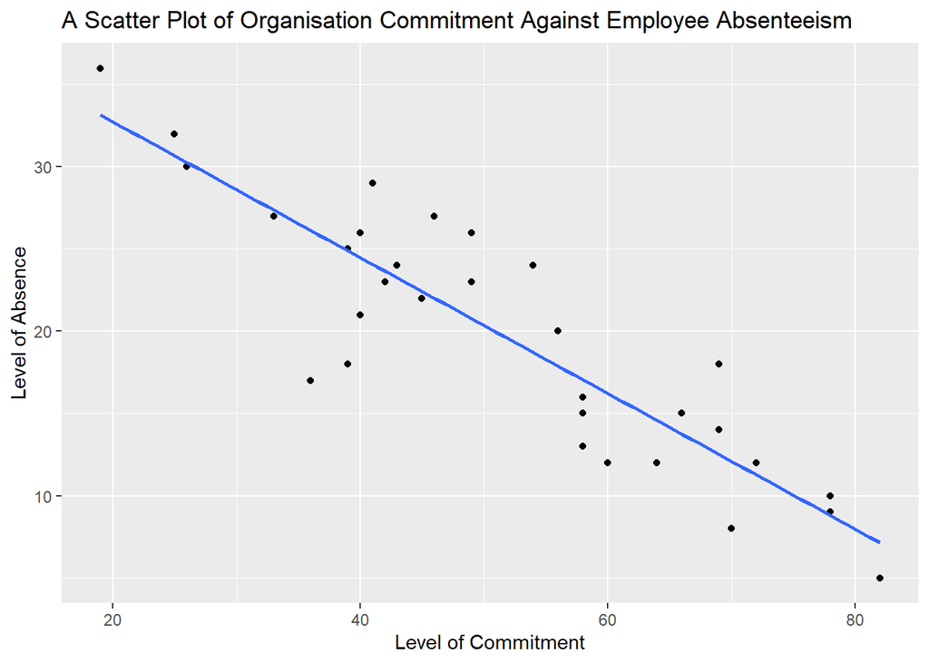

```r
library(ggplot2)
scatterplot<- ggplot(law_firm_data, aes(x = Commitment, y = Absence)) + geom_point()+ geom_smooth(method = lm, se = FALSE) + xlab("Level of Commitment") + ylab("Level of Absence") + ggtitle("A Scatter Plot of Organisation Commitment Against Employee Absenteeism") #geom_smooth(method = lm) adds the regression line. Note that "lm" gives the straight line and "se" gives a shaded region around the line.
scatterplot
```

According to the scatter plot above, as the level of absenteeism increases, the level of commitment decreases. This shows that absenteeism and commitment have a strong negative linear relationship with one another, as commitment increases, the absenteeism reduces. In addition, the data points come to forming somewhat of a downwards diagonal line along the negative gradient line when plotted, proving that there is a correlation between the two variables. There are no visible outliers.

### Multiple Linear Regression

```r
#generate the model
model<- lm(law_firm_data$Absence ~ law_firm_data$Commitment + law_firm_data$Tenure + law_firm_data$Clerk + law_firm_data$Consultant, data = law_firm_data)
summary(model)
```

```
##
## Call:
## lm(formula = law_firm_data$Absence ~ law_firm_data$Commitment +
##     law_firm_data$Tenure + law_firm_data$Clerk + law_firm_data$Consultant,
##     data = law_firm_data)
##
## Residuals:
##     Min      1Q  Median      3Q     Max
## -5.4191 -1.9394  0.0302  1.2563  6.0740
##
## Coefficients:
##                          Estimate Std. Error t value Pr(>|t|)
## (Intercept)              31.09777    4.41690   7.041 1.78e-07 ***
## law_firm_data$Commitment -0.33890    0.07005  -4.838 5.15e-05 ***
## law_firm_data$Tenure      0.04615    0.01818   2.538   0.0175 *
## law_firm_data$Clerk       1.21395    2.42045   0.502   0.6202
## law_firm_data$Consultant  1.86753    1.67983   1.112   0.2764
## ---
## Signif. codes:  0 '***' 0.001 '**' 0.01 '*' 0.05 '.' 0.1 ' ' 1
##
## Residual standard error: 3.207 on 26 degrees of freedom
## Multiple R-squared:  0.8496, Adjusted R-squared:  0.8264
## F-statistic: 36.71 on 4 and 26 DF,  p-value: 2.434e-10
```

### Statistical Significance Of The Independent Variables

```
H0: βi  = 0 & H1: βi ≠ 0
Rejection criteria is as follows: Reject H0 if |Tcal| > Tα/2(n-k)
```

Commitment

Tenure

- Let i= 2 = tenure
- Tα/2(27) = 2.05
- Tcal = 2.538

Clerk Level

- Let i= 3 = Clerk
- Tα/2(27) = 2.05
- Tcal = 0.502

Consultant Level

- Let i= 4 = Consulatant
- Tα/2(27) = 2.05
- Tcal = 1.112

### Significance of the Regression Model at 0.05 Level of Significance

- Y = Β0 + Β1X1 B2X2 + B3X3
- H0: β1 = β2 = β3 = … βk= 0
- H1: Not all slope coefficients are simultaneously zero.

For a given level of significance α = 0.05, numerator degrees of freedom k −1 and denominator degrees of freedom n − k, the critical value is given by F (k −1, n − k)α. Therefore, we will use F (4,26) α = 0.05 = 2.7426. Fcal from the ANOVA table is 36.70775776

Since Fcal = 36.70775776 > F (4,26)0.05 = 2.7426, we reject H0 and conclude that not all slope coefficients are simultaneously zero. Hence there is a significant relationship between the variables in the linear regression model of the data set.

### Prediction And Forecasting

Predicting the level of absence of an employee who has a tenure of 10 years and an organisational commitment index of 50 for all 3 levels of commitment are as follows:

*Absence = 1.214Clerk + 1.868Consulatant + 0.04615Tenure -0.3389 Commitment + 31.098*

1. Absence for Clerk Absence = 1.214(1) + 1.868(0) + 0.04615(10 x12) + -0.3389 (50) + 31.098 Absence = 20.90517271
2. Absence for Consultant Absence = 1.214(0) + 1.868(1) + 0.04615(10 x12) + -0.3389 (50) + 31.098 Absence = 21.55875238
3. Absence for Lawyer Absence = 1.214(0) + 1.868(0) + 0.04615(10 x12) + -0.3389 (50) + 31.098 Absence = 19.69122602